# mnist_visualization_VAE

## MNIST - Visualization & Nonlinear Dimensionality Reduction

Here, we attempt various methods for visualizing a dataset in lower-dimensional space. Thereafter, we observe how dimensionality reduction methods improve classification accuracies, especially in cases when the original data is noisy.

```python
from __future__ import print_function
from __future__ import division
%matplotlib inline

from matplotlib import pyplot as plt
import numpy as np
import torch
import torch.nn as nn
from sklearn import decomposition
import warnings; warnings.simplefilter('ignore')
from numpy.random import permutation as rpm
from plot import plot_images, plot_embedding, plot_embedding_annotation
from dataset import read_mnist, read_mnist_twoview
from utils import resize, x2p, JacobOptimizer, gen_solution
from svm import linear_svm
from vae import VAE
from ptsne import PTSNE

##Additional packages used for visualization and classification
from sklearn.decomposition import KernelPCA
from sklearn.manifold import Isomap
from sklearn.cross_validation import train_test_split
```

## Part 1: Visualization with t-SNE

Let's look at the MNIST dataset again! As before, we divided it into both the training set and development/validation set. Let's visualize the 20% subset of development set. The method employed here is t-SNE. First, we will tune the perplexity hyperparameter.

```python
## TSNE Function
EPS=1.0e-12
torch.manual_seed(1)

class LowEmb(nn.Module):
    """
    Module on computing t-SNE low-dim embedding
    """
    def __init__(self, n, d):
        """
        Set up
        ------
        :in:
        n: int, number of data
        d: int, dimension to reduce to
        """
        super(LowEmb, self).__init__()
        self.Y = nn.Embedding(n, d)


    def forward(self, P, dof, metric):
        """
        Compute divergence between distribution in low and high dimensional space
        ------
        :in:
        P: 2d-array of shape (n_data, n_data), distribution in high-dim data space
        dof: float, degree of freedom of Student-t distribution
        metric: string, type of divergence
        """

        # Compute low-dim distribution Q
        Y = self.Y.weight
        Y2 = torch.sum(Y**2, dim=1, keepdim=True)
        D = Y2 - 2*Y.matmul(Y.t()) + Y2.t()
        Q = (1 - torch.eye(Y.shape[0]).type_as(D))*(1 + D/dof).pow(-(dof + 1)/2.0)
        Q = (Q/Q.sum()).clamp_(min=EPS)

        # Compute discrepency between P and Q
        if metric == 'kl':
            C = torch.sum(P*torch.log(P/Q))
        elif metric == 'reverse_kl':
            C = torch.sum(Q*torch.log(Q/P))
        else:
            #Define Jensen–Shannon divergence
            M = (P+Q)/2
            A = torch.sum(P*torch.log(P/M))
            B = torch.sum(Q*torch.log(Q/M))
            C = 0.5*A + 0.5*B
        return C

class TSNE(object):
    """
    Main Module of t-SNE
    Parameters:
    ------
    n_components: int, dimension to reduce to (default: 2)
    perplexity: float, perplexity of data in high-dimensional space (default: 30)
    n_iters: int, number of iterations for optimization (default: 1000)
    lr: float, learning rate (default: 100)
    opt_type: string, type of optimizer
        "Jacob" | "Adam" | "SGD" | "RMSprop" | "Adagrad" | "Adadelta" (default: "Jacob")
    cuda: bool, whether to use GPU if available (default: True)
    dof: float, degree of freedom of Student-t distribution (default: 1.0)
    metric: string, type of divergence between high and low dimensional space (default: "kl")
    early_exaggeration: float, constant to multiply to high dimensional probability,
        used in early stages of optimization to exaggerate the divergence
        between low and high dimensional space.
        See original t-SNE paper for details (default: 4)
    early_iters: int, number of iterations to do early exaggeration (default: 100)
    log_interval: int, iteration interval to show error (default: 100)
    init: string, initialization of low-dimensional embedding.
        Possible options are "random" | "pca" (default: "pca")

    """
    def __init__(self, n_components=2, perplexity=30.0, n_iters=1000, lr=1.0e2, opt_type='Jacob', cuda=True, dof=1.0,
                 metric='kl', early_exaggeration=4., early_iters=100, log_interval=100, init='pca'):

        self.n_iters = n_iters
        self.lr = lr
        self.opt_type = opt_type
        self.n_components = n_components
        self.perplexity = perplexity
        self.device = torch.device('cuda' if cuda and torch.cuda.is_available() else 'cpu')
        self.dof = dof
        self.metric = metric
        self.early_exaggeration = early_exaggeration
        self.early_iters = early_iters
        self.log_interval = log_interval
        self.init = init

    def fit_transform(self, X):
        """
        Run t-SNE on X
        ------
        :in:
        X: 2d array of shape (n_data, n_dim)
        :out:
        Y: 2d array of shape (n_data, n_components)
        """
        print("Metric: %s" % (self.metric))

        # Compute high-dim distribution matrix P
        P = x2p(X, perplexity=self.perplexity)
        P = (P + P.T)/(2*P.sum())

        # early exageration, P *= Const
        P = P if self.early_exaggeration is None else P * self.early_exaggeration
        P = torch.from_numpy(P.clip(EPS)).type(torch.float)

        lowEmb = LowEmb(X.shape[0], self.n_components)

        # PCA intialization (optional)
        if self.init == 'pca':
            lowEmb.Y.weight.data.copy_(torch.from_numpy(self.pca(X)))

        lowEmb.to(self.device)
        P = P.to(self.device)
        if self.opt_type == 'Jacob':
            optimizer = JacobOptimizer(lowEmb.parameters(), lr=self.lr)
        elif hasattr(torch.optim, self.opt_type):
            optimizer = getattr(torch.optim, self.opt_type)(lowEmb.parameters(), lr=self.lr)
        else:
            raise AttributeError("Valid options for opt_type are [Jacob, Adam, SGD, RMSprop, Adagrad, Adadelta]!")

        # Optimization
        for iter in range(self.n_iters):

            lowEmb.zero_grad()
            l = lowEmb(P, dof=self.dof, metric=self.metric)
            l.backward()

            optimizer.step()

            if (iter + 1) % self.log_interval == 0:
                print("Iteration %d, error: %f" % (iter + 1, l))

            # Stop early exaggeration, use true P value
            if iter == self.early_iters and self.early_exaggeration is not None:
                P = P/self.early_exaggeration

        Y = lowEmb.Y.weight.cpu().detach().numpy()
        return Y

    def pca(self, X):
        """
        Perform PCA on X, as optional preprocessing step
        ------
        :in:
        X: 2d array of shape (n_data, n_dim)
        :out:
        Y: 2d array of shape (n_data, n_components)
        """
        Y = decomposition.PCA(n_components=self.n_components).fit_transform(X).astype(np.float32)
        return Y
```

```
Data path is: ./data/original_distribute.mat
```

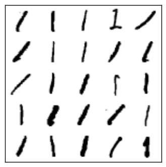

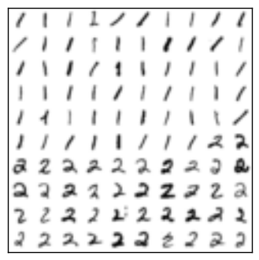

```python
"""
Here, we process the MNIST data required for subsequent steps
"""
np.random.seed(0)

datapath="./data/original_distribute.mat"
print("Data path is: %s" % datapath)

trainData,tuneData,testData=read_mnist(datapath)
test_x_sample = testData
test_x_image = np.reshape(test_x_sample, [test_x_sample.shape[0],28,28]).transpose(0, 2, 1)
train_x_sample = trainData.images
train_x_image = np.reshape(train_x_sample, [train_x_sample.shape[0],28,28]).transpose(0, 2, 1)
train_y_sample = np.reshape(trainData.labels, [train_x_sample.shape[0]])
tune_x_sample = tuneData.images
tune_x_image = np.reshape(tune_x_sample, [tune_x_sample.shape[0],28,28]).transpose(0, 2, 1)
tune_y_sample = np.reshape(tuneData.labels, [tune_x_sample.shape[0]])


"""
Visualize a few input digits
plot_images: Plot a list of selected digits
"""
plot_images(train_x_image[::100], 5, 5, 28, 28)

"""
Visualize more input digits, using smaller scale
"""
train_x_rescale = resize(train_x_image,10,10)
ax = plot_images(train_x_rescale[::100], 10, 10, 10, 10)
plt.show()
```

```
Start TSNE!
Metric: kl
Computing Gaussian for point 0 of 2000...
Computing Gaussian for point 1000 of 2000...
Gaussian for 2000 points done
Iteration 100, error: 14.754060
Iteration 200, error: 1.976471
Iteration 300, error: 1.650559
Iteration 400, error: 1.429503
Iteration 500, error: 1.315570
```

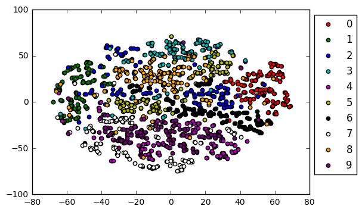

```
Start TSNE!
Metric: kl
Computing Gaussian for point 0 of 2000...
Computing Gaussian for point 1000 of 2000...
Gaussian for 2000 points done
Iteration 100, error: 12.688601
Iteration 200, error: 1.599924
Iteration 300, error: 1.401812
Iteration 400, error: 1.280365
Iteration 500, error: 1.224076
```

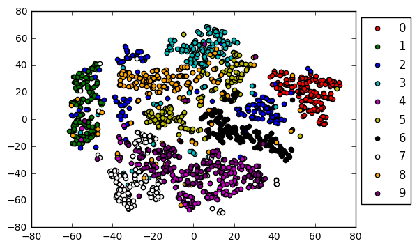

```
Start TSNE!
Metric: kl
Computing Gaussian for point 0 of 2000...
Computing Gaussian for point 1000 of 2000...
Gaussian for 2000 points done
Iteration 100, error: 10.951705
Iteration 200, error: 1.260352
Iteration 300, error: 1.158879
Iteration 400, error: 1.098675
Iteration 500, error: 1.073531
```

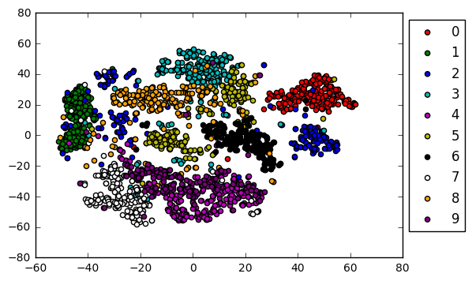

```
Start TSNE!
Metric: kl
Computing Gaussian for point 0 of 2000...
Computing Gaussian for point 1000 of 2000...
Gaussian for 2000 points done
Iteration 100, error: 9.846857
Iteration 200, error: 1.031106
Iteration 300, error: 0.984140
Iteration 400, error: 0.962341
Iteration 500, error: 0.954121
```

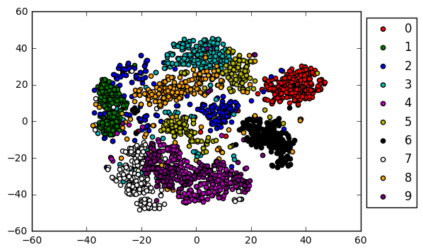

```
Start TSNE!
Metric: kl
Computing Gaussian for point 0 of 2000...
Computing Gaussian for point 1000 of 2000...
Gaussian for 2000 points done
Iteration 100, error: 9.441360
Iteration 200, error: 0.944029
Iteration 300, error: 0.916558
Iteration 400, error: 0.904310
Iteration 500, error: 0.900345
```

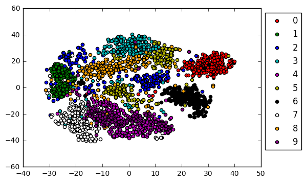

```
Start TSNE!
Metric: kl
Computing Gaussian for point 0 of 2000...
Computing Gaussian for point 1000 of 2000...
Gaussian for 2000 points done
Iteration 100, error: 8.326213
Iteration 200, error: 0.689934
Iteration 300, error: 0.687573
Iteration 400, error: 0.687174
Iteration 500, error: 0.687126
```

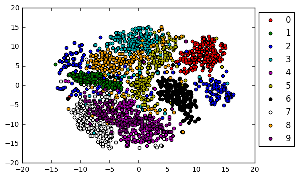

```
Start TSNE!
Metric: kl
Computing Gaussian for point 0 of 2000...
Computing Gaussian for point 1000 of 2000...
Gaussian for 2000 points done
Iteration 100, error: 6.822843
Iteration 200, error: 0.319349
Iteration 300, error: 0.319274
Iteration 400, error: 0.319274
Iteration 500, error: 0.319274
```

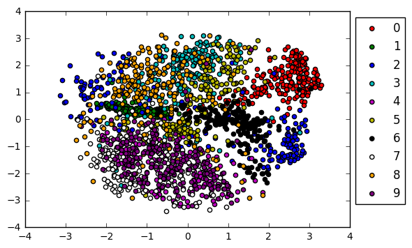

```python
"""
Visualize 20% dev set using t-SNE
First, we vary perlexity.

Perlexity = 3,10,30,70,100,300,1000
"""

###FIRST VARY PERPLEXITY
size_tune = 5
for i in [3,10,30,70,100,300,1000]:
    print("Start TSNE!")
    z_tsne_tune = TSNE(n_components=2, perplexity=i, n_iters=500, cuda=True, dof=1.0,
                       metric="kl", early_exaggeration=4, init='pca').fit_transform(tune_x_sample[::size_tune])
    plot_embedding(z_tsne_tune, tune_y_sample[::size_tune])
#    plot_embedding_annotation(z_tsne_tune, resize(tune_x_image[::size_tune],10,10), 0.001)
    plt.show()
```

```
Start TSNE! JS Divergence, Perp=30
Metric: others
Computing Gaussian for point 0 of 2000...
Computing Gaussian for point 1000 of 2000...
Gaussian for 2000 points done
Iteration 100, error: 1.151552
Iteration 200, error: 0.328892
Iteration 300, error: 0.279822
Iteration 400, error: 0.246379
Iteration 500, error: 0.228586
```

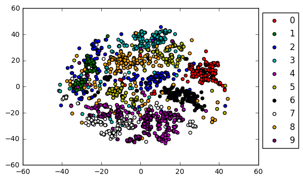

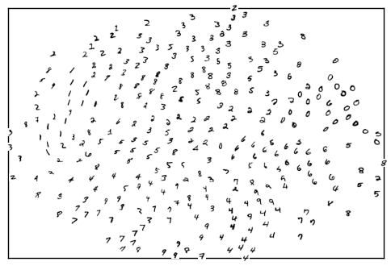

```
Start TSNE! JS Divergence, Perp=100
Metric: others
Computing Gaussian for point 0 of 2000...
Computing Gaussian for point 1000 of 2000...
Gaussian for 2000 points done
Iteration 100, error: 0.928732
Iteration 200, error: 0.226581
Iteration 300, error: 0.199676
Iteration 400, error: 0.184650
Iteration 500, error: 0.177583
```

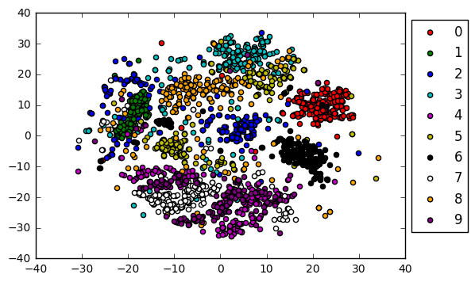

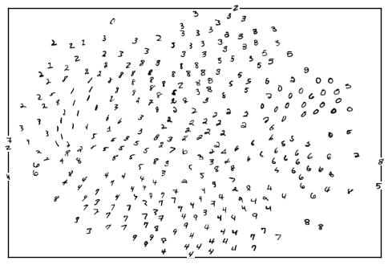

```python
"""
Test new divergence metric
JENSEN-SHANNON DIVERGENCE
"""
#Jensen–Shannon_divergence
#Fix perp=30
print("Start TSNE! JS Divergence, Perp=30")
z_tsne_tune_js = TSNE(n_components=2, perplexity=30, n_iters=500, cuda=True, dof=1.0,
                   metric="others", early_exaggeration=4, init='pca').fit_transform(tune_x_sample[::size_tune])
plot_embedding(z_tsne_tune_js, tune_y_sample[::size_tune])
plot_embedding_annotation(z_tsne_tune_js, resize(tune_x_image[::size_tune],10,10), 0.001)
plt.show()

#Fix perp=70
print("Start TSNE! JS Divergence, Perp=100")
z_tsne_tune_js = TSNE(n_components=2, perplexity=100, n_iters=500, cuda=True, dof=1.0,
                   metric="others", early_exaggeration=4, init='pca').fit_transform(tune_x_sample[::size_tune])
plot_embedding(z_tsne_tune_js, tune_y_sample[::size_tune])
plot_embedding_annotation(z_tsne_tune_js, resize(tune_x_image[::size_tune],10,10), 0.001)
plt.show()
```

## Other Dimensionality Reduction Methods for Visualization

Now, we will try out other dimensionality reduction methods. First, we will do Kernel PCA in detail. Note that we will also look at IsoMap, but only briefly, and will not go into detail for Isomap.

```python
"""
Visualize 20% dev set using other dimensionality reduction methods
Choose Kernel PCA - Use Gaussian/rbf kernel

gamma : float, default=1/n_features
"""

def my_visualize_emb(train_data, gamma_input):
    """
    :in: train_data: 2d array of shape (n_data, n_dim), training data of my method
    :out: train_features: 2d array of shape (n_data, 2), 2-d feature of training data
    """
    #Perform Kernel PCA
    transformer = KernelPCA(n_components=2, kernel='rbf', gamma=gamma_input)
    transformed_data = transformer.fit_transform(train_data)
    return transformed_data

#gamma_list = list(np.arange(0.001, 0.01, 0.0005))
gamma_list = [0.0095, 0.0085, 0.0075, 0.0055, 0.004, 0.0035]

for gamma in gamma_list:
    print("Start My Method! Gamma = ", gamma)
    z_my_tune = my_visualize_emb(tune_x_sample[::5], gamma)
    plot_embedding(z_my_tune, tune_y_sample[::5])
#   plot_embedding_annotation(z_my_tune, resize(tune_x_image[::5],10,10), 0.001)
    plt.show()
```

[output not shown]

```
Start My Method! Nearest Neighbors =  5
```

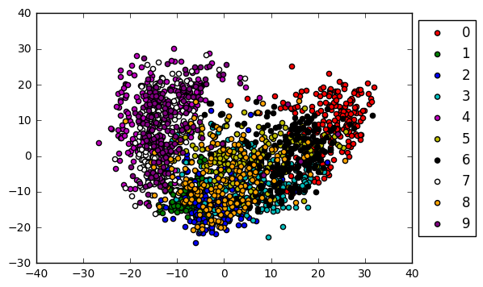

```
Start My Method! Nearest Neighbors =  15
```

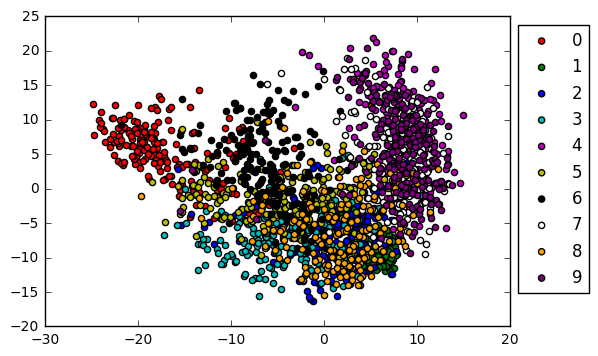

```
Start My Method! Nearest Neighbors =  30
```

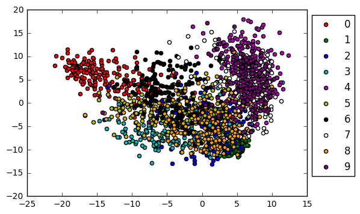

```
Start My Method! Nearest Neighbors =  50
```

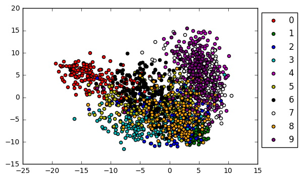

```
Start My Method! Nearest Neighbors =  75
```

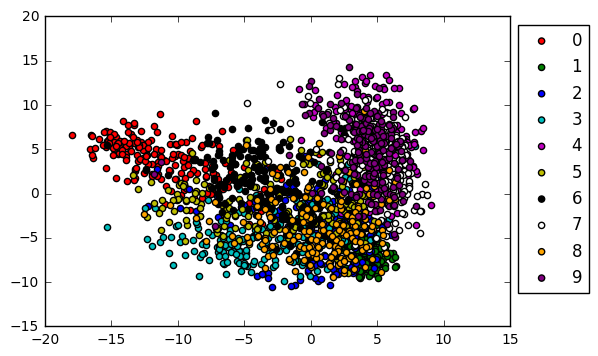

```python
"""
Visualize 20% dev set using other dimensionality reduction methods
Choose IsoMap
hyperparameter: n = number of neighbors
"""

def my_visualize_Isomap(train_data, neighbors):
    #Perform Isomap
    transformer = Isomap(n_components=5, eigen_solver='dense',
                         n_neighbors=neighbors)
    transformed_data = transformer.fit_transform(train_data)
    return transformed_data

neighbor_list = [5,15,30,50,75]

for n in neighbor_list:
    print("Start My Method! Nearest Neighbors = ", n)
    z_my_tune = my_visualize_Isomap(tune_x_sample[::5], n)
    plot_embedding(z_my_tune, tune_y_sample[::5])
#    plot_embedding_annotation(z_my_tune, resize(tune_x_image[::5],10,10), 0.001)
    plt.show()
```

## Visualization Method using Parametric SNE

Next, we will explore a parametric method to visualize a given dataset. This implies that the algorithm will be trained on a separate set of data, before we apply it to a new dataset to assists in lower-dimensional visualization.

```
Epoch: 1, train loss: 4.8466, dev loss: 2.9551
Epoch: 2, train loss: 3.8491, dev loss: 2.8612
Epoch: 3, train loss: 3.6892, dev loss: 2.8326
Epoch: 4, train loss: 3.6352, dev loss: 2.7984
Epoch: 5, train loss: 3.5856, dev loss: 2.7644
Epoch: 6, train loss: 3.5413, dev loss: 2.7254
Epoch: 7, train loss: 3.4987, dev loss: 2.6808
Epoch: 8, train loss: 3.4545, dev loss: 2.6392
Epoch: 9, train loss: 3.4103, dev loss: 2.5941
Epoch: 10, train loss: 3.3636, dev loss: 2.5487
30
```

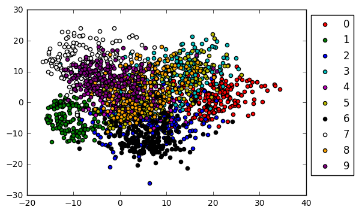

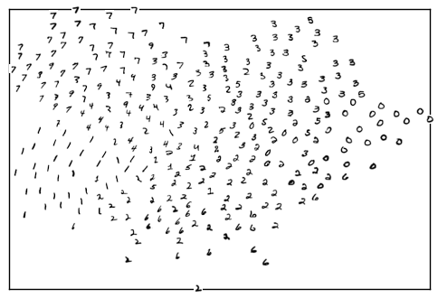

```
Epoch: 1, train loss: 4.0118, dev loss: 2.3173
Epoch: 2, train loss: 3.1876, dev loss: 2.1892
Epoch: 3, train loss: 2.9868, dev loss: 2.1601
Epoch: 4, train loss: 2.9313, dev loss: 2.1361
Epoch: 5, train loss: 2.8988, dev loss: 2.0962
Epoch: 6, train loss: 2.8563, dev loss: 2.0447
Epoch: 7, train loss: 2.8068, dev loss: 1.9972
Epoch: 8, train loss: 2.7625, dev loss: 1.9557
Epoch: 9, train loss: 2.7224, dev loss: 1.9175
Epoch: 10, train loss: 2.6814, dev loss: 1.8809
70
```

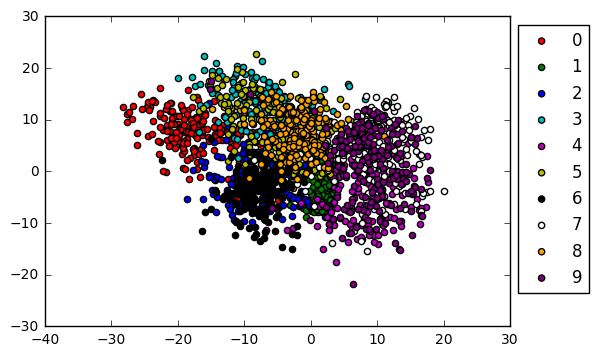

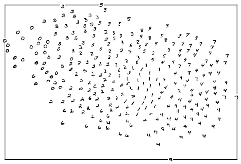

```
Epoch: 1, train loss: 3.6564, dev loss: 2.0356
Epoch: 2, train loss: 2.8782, dev loss: 1.9424
Epoch: 3, train loss: 2.7205, dev loss: 1.9065
Epoch: 4, train loss: 2.6627, dev loss: 1.8687
Epoch: 5, train loss: 2.6152, dev loss: 1.8411
Epoch: 6, train loss: 2.5779, dev loss: 1.8156
Epoch: 7, train loss: 2.5428, dev loss: 1.7843
Epoch: 8, train loss: 2.5074, dev loss: 1.7456
Epoch: 9, train loss: 2.4712, dev loss: 1.7075
Epoch: 10, train loss: 2.4330, dev loss: 1.6719
100
```

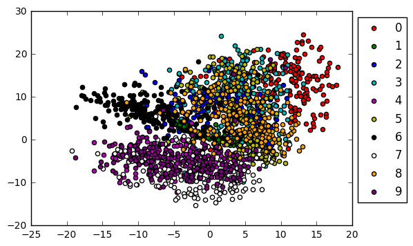

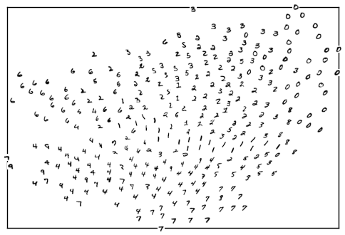

```python
"""
Q3.1.5
Visualize 20% dev set using training on a larger training set
Since this should be parametric, we will use parmetric t-SNE.
Keep perp within the range of 30 for easy comparison.
Repeat to make sure results are not perp-dependent
"""

training_1 = train_x_sample[::10]
tuning_1 = train_x_sample[::30]

for perp in [30, 70, 100]:
    ptsne = PTSNE(n_inputs=784, n_components=2, batch_size=5000, cuda=True, perplexity=perp, dof=1)
    ptsne.fit(training_1, tuning_1, epochs=10)

    z_separate = ptsne.transform(tune_x_sample[::5])
    plot_embedding(z_separate, tune_y_sample[::5])
    plot_embedding_annotation(z_separate, resize(tune_x_image[::5],10,10), 0.001)
    print(perp)
    plt.show()
```